# Assignment 3

Data set Pathway and Network Analysis

Keren Zhang

2025-04-02

## Introduction

In their 2024 study, Liu and colleagues focused on a type of lung cancer called lung adenocarcinoma (LUAD), which is one of the most common and deadliest forms of cancer globally(Zappa & Mousa, 2016). Even after doctors surgically remove the tumor, this cancer often spreads to other parts of the body in about half of the patientsr(Liu et al., 2024). To better understand and find ways to treat this spread, called metastasis, they developed a new experimental model using patient-derived organoids (PDOs). PDOs are three-dimensional cell cultures taken from patients’ tumors that act like the actual biological environment of lung cancer. The study also used metastasis-derived organoids (MDOs), taken from different places where the cancer spread, like the brain, diaphragm, liver, and gallbladder, to study and find out more about what causes LUAD to spread and possible ways to treat it.

## Previous Work

For this project, the RNA sequencing data used came from three different groups: patient-derived organoids (PDO), metastasis-derived organoids (MDO), and control group human tumor samples. This data was obtained from the Lung Adenocarcinoma [(LUAD)](https://pubmed.ncbi.nlm.nih.gov/39413736/) study, which is documented and accessible under the GEO accession number GSE276387.

### A1

In A1, the orginal `57445` data set was pre-processed and the genes were mapped to HUGO Gene Nomenclature Committee (HGNC) symbols. Missing values and duplicated genes were removed to ensure data integrity. Outliers were identified and removed to enhance the robustness of the analysis. Finally the Trimmed Mean of M-values (TMM) method was employed for normalization to minimize technical variance.

The final resulting data set has `17195` genes over `14` samples (5 Patient Derived Organoid samples, 5 Metastasis Derived Organoid samples, and 4 Human Tumor Samples).

### A2

#### Thresholded over-representation analysis

Then `g:Profiler` to analyze gene sets from differentially expressed genes in MDO and PDO. For this analysis, gene sets were categorized into up-regulated, down-regulated, and all genes to capture the complete spectrum of gene expression changes.The annotation sources utilized included `GO:BP` for biological processes, `KEGG` for metabolic and signaling pathways, `REAC` for comprehensive pathway interactions, and `WP` for the latest pathway information.

For **MDO**, `2855` upregulated and `3058` downregulated gene sets were identified, with a total of `4507` gene sets across all genes.

Upon filtering for gene sets containing between `5` to `500` genes, the enriched pathways provided insights into the cellular functions most impacted by gene expression changes:

In **MDO**, the top upregulated pathways included **T-cell activation** and **proliferation**, indicating an immune response component, whereas downregulated pathways highlighted deficiencies in **DNA repair** and **cell cycle regulation**.

In **PDO**, top pathways for upregulated genes focused on **epidermis development** and **differentiation**, which might reflect the tissue-specific origins and adaptations of these organoids. The top pathways for downregulated genes included smooth muscle **cell differentiation** and various **signaling pathways** like BMP and MAP kinase.

## Load Libraries

```r
if (! requireNamespace("kableExtra", quietly = TRUE)) {
  install.packages("kableExtra")
}

if (! requireNamespace("ComplexHeatmap", quietly = TRUE)) {
  BiocManager::install("ComplexHeatmap")
}

if (! requireNamespace("circlize", quietly = TRUE)) {
  BiocManager::install("circlize")
}

if (!requireNamespace("BiocManager", quietly = TRUE))
  install.packages("BiocManager")
BiocManager::install("GEOquery")


#install required R and bioconductor packages for GSEA
tryCatch(expr = { library("RCurl")},
         error = function(e) {
           install.packages("RCurl")},
         finally = library("RCurl"))

library(ggplot2)
library(knitr)
library(kableExtra)
library(dplyr)
library(GEOquery)

# wraps lines that are too long
knitr::opts_chunk$set(tidy.opts=list(width.cutoff=80), tidy=TRUE)
# set default behaviors for all chunks
knitr::opts_chunk$set(warning = FALSE, message = FALSE)
```

## Load data

In this assignment, we’ll start with the result from the comparison between Tumor and PDO (Patient-Derived Organoids),which had **631** genes that are significantly differentially expressed. It will be loaded it as an `.rds` file. The `qlf_PDO_hits.rds` file can be generated by running saveRDS(qlf_PDO_hits, ‘qlf_PDO_hits.rds’) after running all code chunks in A2

```r
# Render notebook 2 rmarkdown::render('../A2/A2_KZ.Rmd') saveRDS(qlf_PDO_hits,
# 'qlf_PDO_hits.rds')


# load the output of the exact test model from Assignment 2
PDO_hits <- readRDS("qlf_PDO_hits.rds")
PDO_output <- PDO_hits$table


# Calculate the 'rank' for each entry in the PDO_output data frame 'rank' is
# computed as the negative log base 10 of the PValue multiplied by the sign of
# the logFC (log Fold Change) Transforms the P-value into a more interpretable
# scale and combines it with the direction of change (up or down)
PDO_output[, "rank"] <- -log(PDO_output$PValue, base = 10) * sign(PDO_output$logFC)

# Sort the PDO_output data frame by the 'rank' column in ascending order Place
# the most negatively significant results (significant downregulation) at the
# top and the most positively significant results (significant upregulation) at
# the bottom
PDO_output <- PDO_output[order(PDO_output$rank), ]
```

## Non-thresholded Gene set Enrichment Analysis

In Assignment 2, we utilized thresholded over-representation analysis (ORA) to explore the LUAD dataset. However, ORA has notable limitations. Firstly, the choice of threshold is subjective, leading to variability in results depending on the threshold set. Different thresholds can significantly alter the analysis outcome, making the selection process somewhat arbitrary. Secondly, ORA has a tendency to overlook subtler signals within the data. This occurs because the method excludes data points that do not meet the predefined threshold, potentially missing important but less pronounced trends or patterns.

To address these drawbacks, for this assignment, the Gene Set Enrichment Analysis (GSEA) will be performed. GSEA offers a more nuanced approach by analyzing data without the need for arbitrary threshold settings. This method allows for the inclusion of all gene sets in the analysis, enhancing our ability to detect both strong and weak signals across the dataset. Through GSEA, we aim to gain a comprehensive understanding of the enrichment patterns within our data, ensuring that no significant patterns are overlooked due to thresholding constraints.

There are two important steps for the GSEA analysis. Firstly, a rank file should be created, which serves as the foundation for the analysis:

```r
# Create a rank file (.rnk) for GSEA
rnk <- data.frame(rownames(PDO_output), PDO_output$rank)
colnames(rnk) <- c("GeneName", "rank")
write.table(rnk, file = "./Tumour_vs_PDO.rnk", sep = "\t", col.name = TRUE, row.names = FALSE,
    quote = FALSE)
```

Secondly, a pathway definition file, commonly in the GMT (Gene Matrix Transposed) format, is required. This file compiles curated gene sets representing various biological pathways, processes, or other functional groupings:

```r
# Load GSEA related variables
gsea_jar = "~/projects/A3/GSEA_4.3.3/gsea-cli.sh"
working_dir = "~/projects/A3"
output_dir = "~/projects/A3"
analysis_name = "Tumour_vs_PDO"
rnk_file = "Tumour_vs_PDO.rnk"
dest_gmt_file = ""
```

```r
# Download the latest pathway definition file from BaderLab released on March
# 1st, 2025. (As of April 2nd, 2025)
if (dest_gmt_file == "") {
    gmt_url = "http://download.baderlab.org/EM_Genesets/current_release/Human/symbol/"

    # list all the files on the server
    filenames = getURL(gmt_url)
    tc = textConnection(filenames)
    contents = readLines(tc)
    close(tc)

    # get the gmt that has all the pathways and does not include terms inferred
    # from electronic annotations(IEA) start with gmt file that has pathways
    # only and GO Biological Process only.
    rx = gregexpr("(?<=<a href=\")(.*.GOBP_AllPathways_noPFOCR_no_GO_iea.*.)(.gmt)(?=\">)",
        contents, perl = TRUE)
    gmt_file = unlist(regmatches(contents, rx))

    dest_gmt_file <- file.path(output_dir, gmt_file)

    # check if this gmt file already exists
    if (!file.exists(dest_gmt_file)) {
        download.file(paste(gmt_url, gmt_file, sep = ""), destfile = dest_gmt_file)
    }
}
```

```r
# Construct the command to run GSEA PreRanked analysis with specified
# parameters cmd <- paste('', gsea_jar, 'GSEAPreRanked -gmx', dest_gmt_file, #
# Specify the gene sets file (GMT) '-rnk', file.path(working_dir, rnk_file), #
# Define the ranking file path # Analysis settings: no collapsing, 1000
# permutations, weighted scoring '-collapse false -nperm 1000 -scoring_scheme
# weighted', '-rpt_label', analysis_name, # Label for the report generated by
# GSEA # Plot top 20 sets, seed for reproducibility, max gene set size '
# -plot_top_x 20 -rnd_seed 12345 -set_max 200', ' -set_min 15 -zip_report
# false', # Minimum gene set size, no zip compression for the report ' -out',
# output_dir, # Output directory for GSEA results ' > gsea_output.txt', sep='
# ') # Redirect output to a text file # Execute the command using system call
# system(cmd)
```

### 1.1 What method did you use? What genesets did you use? Make sure to specify versions and cite your methods.

In this analysis, the Gene Set Enrichment Analysis (GSEA) method was employed, specifically utilizing the GSEAPreRanked tool (Subramanian et al., 2005). GSEAPreRanked is a component of the broader GSEA approach, designed to analyze gene lists that have already been ranked based on their association with a phenotype of interest. It is particularly advantageous for its ability to detect subtle changes in gene expression that may be overlooked by methods requiring strict thresholding, such as Over-Representation Analysis (ORA).

**Versions and Inputs**

- GSEA Software: GSEA version `4.3.3`, developed by the Broad Institute.
- Rank File: [Rank file](https://github.com/bcb420-2025/Keren_Zhang/blob/main/A3/Tumour_vs_PDO.rnk) created from the LUAD data set
- Gene Set: pathway definition GMT file from Bader Lab released on March 1st,

**Parameters**

- Number of permutation: `1000`
- Collapse/Remap to gene symbols: `Collapse False` (no collapse)
- Scoring Scheme: `weighted`
- Max size: `200`
- Min size: `15`

We set the number of permutations to 1000, allowing for good statistical validation of the enrichment scores. The parameter Collapse False indicates that gene symbols will not be collapsed or remapped, thus preserving the original specificity of the gene identifiers in the analysis. The scoring scheme is set to weighted, which considers both the ranking of gene sets and their correlation with the phenotype, thereby enhancing the sensitivity to detect genuine biological differences. Additionally, the gene set size limits are defined with a minimum of 15 and a maximum of 200 genes, ensuring that only gene sets with sufficient, yet manageable, numbers of genes are considered, balancing comprehensiveness with statistical reliability.

There are two tables that will be created after running GSEA: one .tsv file for the up-regulated genes, and one .tsv file for the down-regulated genes.

```r
gsea_output_dir <- file.path(working_dir, "Tumour_vs_PDO.GseaPreranked.1743500855381")


# Reading the GSEA output for upregulated / positive enrichments
gsea_upreg <- read.table(file = "gsea_report_for_na_pos_1743500855381.tsv", sep = "\t",
    header = TRUE, fill = TRUE)

# Reading the GSEA output for downregulated / negative enrichments
gsea_downreg <- read.table(file = "gsea_report_for_na_neg_1743500855381.tsv", sep = "\t",
    header = TRUE, fill = TRUE)
```

### 1.2 Summarize your enrichment results.

In the conducted GSEA, a total of `5,743` gene sets were considered out of an initial pool of `19,372`, following the application of size filters (minimum 15 genes and maximum 200 genes per set). This filtration excluded 13,629 gene sets due to size constraints.

The pre-ranked analysis identified `3432` up-regulated gene sets out of `5743` total gene sets, with `718` gene sets are significantly enriched at nominal pvalue < 5%, `281` gene sets are significantly enriched at nominal pvalue < 1%, and `587` gene sets are significant at FDR < 25%, which is an indication of significant enrichment. In terms of the down-regulated gene sets, `2311` down-regulated gene sets out of `5743` gene sets are identified. `679` gene sets are significantly enriched at nominal pvalue < 5%, `372` gene sets are significantly enriched at nominal pvalue < 1%, and `821` gene sets are significantly enriched at FDR < 25%, which is also an indication of significant enrichment.

After performing the above GSEA analysis and examining the output, it was found that:

- the most significant pathway in the upregulated genes was `KERATINIZATION` with a normalized enrichment score of `0.8166343` and a normalised enrichment score of `2.981227`. The nominal p-value, FDR q-value and FWER p-value was `0.0`. There were `57` genes in the gene set with `KRT6A` being the top gene.
- the most significant pathway in the deregulated genes was `IMMUNOREGULATORY INTERACTIONS BETWEEN A LYMPHOID AND A NON-LYMPHOID CELL` with enrichment score of `-0.6894601` and normalised enrichment score of `-2.9009557`. The nominal p-value, FDR q-value and FWER p-value was `0.0`, similar to above. There were `129` genes in the gene set with `CDH1` being the top gene.

(See Journal for more details)

```r
# Split the 'NAME' column in the 'gsea_upreg' data frame to extract pathway
# names and data sources.  The names are split based on the '%' delimiter, and
# the first two elements are retained.
pathway_names <- sapply(stringr::str_split(gsea_upreg$NAME, "%"), "[", 1:2)
# Transpose the resulting matrix to align with the data frame structure.
pathway_names <- t(pathway_names)

# Combine the extracted 'pathway_names' matrix with the original 'gsea_upreg'
# data frame.  This adds two new columns to the beginning of 'gsea_upreg'.
gsea_upreg <- cbind(pathway_names, gsea_upreg)

# Select only the essential columns from the data frame for further analysis.
# The columns selected are the two newly added pathway name columns, and the
# 'SIZE', 'NES', 'NOM.p.val', and 'FDR.q.val' columns.
upreg <- gsea_upreg[, c("1", "2", "SIZE", "NES", "NOM.p.val", "FDR.q.val")]

# Rename the columns of the 'upreg' data frame to make them more
# human-readable.  This clarifies the content of each column in output and
# subsequent operations.
colnames(upreg) <- c("Term", "Data Source", "Size", "Normalized Enrichment Score",
    "Nominal p-value", "FDR q-value")

# Format the 'upreg' data frame for presentation using the kableExtra package.
# Only display rows where the 'Nominal p-value' is less than 0.05, indicating
# significant enrichment.  Output is formatted as HTML with precision up to 10
# decimal places for more detailed viewing.
kableExtra::kable_paper(knitr::kable(head(upreg[which(upreg$"Nominal p-value" < 0.05),
    ], 10), format = "html", digits = 10))
```

| Term | Data Source | Size | Normalized Enrichment Score | Nominal p-value | FDR q-value |
| --- | --- | --- | --- | --- | --- |
| KERATINIZATION | REACTOME DATABASE ID RELEASE 91 | 57 | 2.981227 | 0 | 0 |
| FORMATION OF THE CORNIFIED ENVELOPE | REACTOME DATABASE ID RELEASE 91 | 37 | 2.700733 | 0 | 0 |
| EPIDERMIS DEVELOPMENT | GOBP | 127 | 2.699058 | 0 | 0 |
| SKIN DEVELOPMENT | GOBP | 96 | 2.626591 | 0 | 0 |
| KERATINOCYTE DIFFERENTIATION | GOBP | 47 | 2.588737 | 0 | 0 |
| EPIDERMAL CELL DIFFERENTIATION | GOBP | 66 | 2.512080 | 0 | 0 |
| PANCREATIC CANCER SUBTYPES | WIKIPATHWAYS_20250210 | 25 | 2.405699 | 0 | 0 |
| INTERMEDIATE FILAMENT CYTOSKELETON ORGANIZATION | GOBP | 48 | 2.331920 | 0 | 0 |
| INTERMEDIATE FILAMENT-BASED PROCESS | GOBP | 49 | 2.324767 | 0 | 0 |
| ESTABLISHMENT OF SKIN BARRIER | GOBP | 17 | 2.319888 | 0 | 0 |

**Table 1.** *Top 10 significantly up-regulated gene sets as outputted by GSEA pre-ranked analysis, ordered by descending normalized enrichment score. Significance is determined by having a nominal p-value < 0.05.*

```r
# Split the 'NAME' column in the 'gsea_downreg' data frame to extract pathway
# names and data sources.  The names are split based on the '%' delimiter, and
# the first two elements are retained.
pathway_names <- sapply(stringr::str_split(gsea_downreg$NAME, "%"), "[", 1:2)
# Transpose the resulting matrix to align with the data frame structure.
pathway_names <- t(pathway_names)

# Combine the extracted 'pathway_names' matrix with the original 'gsea_downreg'
# data frame.  This adds two new columns to the beginning of 'gsea_downreg'.
gsea_downreg <- cbind(pathway_names, gsea_downreg)

# Select only the essential columns from the data frame for further analysis.
# The columns selected are the two newly added pathway name columns, and the
# 'SIZE', 'NES', 'NOM.p.val', and 'FDR.q.val' columns.
downreg <- gsea_downreg[, c("1", "2", "SIZE", "NES", "NOM.p.val", "FDR.q.val")]

# Rename the columns of the 'downreg' data frame to make them more
# human-readable.  This clarifies the content of each column in output and
# subsequent operations.
colnames(downreg) <- c("Term", "Data Source", "Size", "Normalized Enrichment Score",
    "Nominal p-value", "FDR q-value")

# Format the 'downreg' data frame for presentation using the kableExtra
# package.  Only display rows where the 'Nominal p-value' is less than 0.05,
# indicating significant enrichment.  Output is formatted as HTML with
# precision up to 10 decimal places for more detailed viewing.
kableExtra::kable_paper(knitr::kable(head(downreg[which(downreg$"Nominal p-value" <
    0.05), ], 10), format = "html", digits = 10))
```

| Term | Data Source | Size | Normalized Enrichment Score | Nominal p-value | FDR q-value |
| --- | --- | --- | --- | --- | --- |
| IMMUNOREGULATORY INTERACTIONS BETWEEN A LYMPHOID AND A NON-LYMPHOID CELL | REACTOME DATABASE ID RELEASE 91 | 129 | -2.900956 | 0 | 0 |
| INITIAL TRIGGERING OF COMPLEMENT | REACTOME | 56 | -2.658123 | 0 | 0 |
| CD22 MEDIATED BCR REGULATION | REACTOME DATABASE ID RELEASE 91 | 45 | -2.639774 | 0 | 0 |
| COMPLEMENT CASCADE | REACTOME DATABASE ID RELEASE 91 | 75 | -2.630104 | 0 | 0 |
| CLASSICAL ANTIBODY-MEDIATED COMPLEMENT ACTIVATION | REACTOME DATABASE ID RELEASE 91 | 47 | -2.604050 | 0 | 0 |
| CREATION OF C4 AND C2 ACTIVATORS | REACTOME | 50 | -2.593291 | 0 | 0 |
| EXTRAFOLLICULAR AND FOLLICULAR B CELL ACTIVATION BY SARS COV 2 | WIKIPATHWAYS_20250210 | 49 | -2.588963 | 0 | 0 |
| HALLMARK_ALLOGRAFT_REJECTION | MSIGDBHALLMARK | 148 | -2.586953 | 0 | 0 |
| REGULATION OF COMPLEMENT CASCADE | REACTOME DATABASE ID RELEASE 91 | 70 | -2.582423 | 0 | 0 |
| FCGR ACTIVATION | REACTOME | 52 | -2.531543 | 0 | 0 |

**Table 2.** *Top 10 significantly down-regulated gene sets as outputted by GSEA pre-ranked analysis, ordered by descending normalized enrichment score. Significance is determined by having a nominal p-value < 0.05.*

### 1.31 How do these results compare to the results from the thresholded analysis in Assignment #2. Compare qualitatively.

As A2 data is already loaded from the previous step, here is a recap of the top up-regulated and down-regulated genes from the PDO vs. Tumour group based on g:profiler respectively (for details please see [A2](https://github.com/bcb420-2025/Keren_Zhang/blob/main/A2/A2_KZ.Rmd)):

```r
gost_up_filtered <- readRDS("gost_up_filtered.rds")

knitr::kable(gost_up_filtered[1:10, c("term_size", "term_name")], row.names = FALSE,
    )
```

| term_size | term_name |
| --- | --- |
| 231 | epidermis development |
| 168 | skin development |
| 142 | epidermal cell differentiation |
| 102 | keratinocyte differentiation |
| 454 | epithelial cell differentiation |
| 85 | intermediate filament cytoskeleton organization |
| 86 | intermediate filament-based process |
| 71 | intermediate filament organization |
| 21 | establishment of skin barrier |
| 33 | keratinization |

**Table 3.** *Top significant gene sets for up-regulated genes for the PDO Group using g:profiler in A2*

```r
gost_down_filtered <- readRDS("gost_down_filtered.rds")
knitr::kable(gost_down_filtered[1:10, c("term_size", "term_name")], row.names = FALSE,
    )
```

| term_size | term_name |
| --- | --- |
| 39 | smooth muscle cell differentiation |
| 44 | negative regulation of BMP signaling pathway |
| 23 | vascular associated smooth muscle cell differentiation |
| 166 | calcium-mediated signaling |
| 78 | regulation of BMP signaling pathway |
| 126 | negative regulation of transmembrane receptor protein serine/threonine kinase signaling pathway |
| 26 | regulation of smooth muscle cell differentiation |
| 117 | BMP signaling pathway |
| 84 | negative regulation of cellular response to growth factor stimulus |
| 434 | leukocyte differentiation |

**Table 4.** *Top significant gene sets for down-regulated genes for the PDO Group using g:profiler in A2*

For better comparison, I will put them in the same table side by side:

```r
# Extract the 'Term' column from the 'upreg' data frame where the 'Nominal
# p-value' is less than 0.05, selecting the top 10 results.
top_terms_upreg <- head(upreg[which(upreg$"Nominal p-value" < 0.05), "Term"], 10)

# Extract the 'term_name' column from the 'gost_up_filtered' data frame,
# selecting the top 10 entries.
top_term_names_gost <- gost_up_filtered[1:10, "term_name"]

# Convert all terms to lowercase for uniformity
top_terms_upreg <- tolower(top_terms_upreg)
top_term_names_gost <- tolower(top_term_names_gost)

# Combine the two columns into a new data frame.  Replace dots in the column
# name with spaces and apply lowercase transformation.
combined_terms <- data.frame(`Top Up-Regulated Terms From A2 ORA` = top_term_names_gost,
    `Top Up-regulated Terms From A3 GSEA` = top_terms_upreg)
names(combined_terms) <- gsub("\\.", " ", names(combined_terms))  # Remove dots from column names

# Use `knitr::kable()` to create a formatted table from the combined data
# frame.
knitr::kable(combined_terms, caption = "Comparison of Terms from Two Analyses", row.names = FALSE,
    format = "html")
```

Comparison of Terms from Two Analyses

| Top Up Regulated Terms From A2 ORA | Top Up regulated Terms From A3 GSEA |
| --- | --- |
| epidermis development | keratinization |
| skin development | formation of the cornified envelope |
| epidermal cell differentiation | epidermis development |
| keratinocyte differentiation | skin development |
| epithelial cell differentiation | keratinocyte differentiation |
| intermediate filament cytoskeleton organization | epidermal cell differentiation |
| intermediate filament-based process | pancreatic cancer subtypes |
| intermediate filament organization | intermediate filament cytoskeleton organization |
| establishment of skin barrier | intermediate filament-based process |
| keratinization | establishment of skin barrier |

**Table 5.** *Top 10 pathways related to up-regulated genes, as outputted by threshold Over-Representation Analysis (ORA) (left) and non-thresholded GSEA analysis (right). Results are converted to lower case for better readability.*

Both analyses identify several similar biological themes or pathways related to skin and epidermal development (e.g., “epidermis development”, “skin development”), differentiation processes (e.g., “epidermal cell differentiation”, “keratinocyte differentiation”), and structural components (e.g., “intermediate filament cytoskeleton organization”). This overlap confirms that both methods are capturing critical biological pathways relevant to the study context. However, GSEA seems to provide a broader perspective by including terms like “formation of the cornified envelope,” which specifies a particular aspect of skin development not captured by the ORA. This indicates GSEA’s strength in detecting specific biological processes within a broader theme. Also, GSEA’s inclusion of “pancreatic cancer subtypes” suggests that it can uncover associations not just restricted to the most statistically significant gene sets but also those that are subtly represented in the dataset. ORA might miss such associations due to its reliance on a pre-defined significance threshold.

```r
# Extract the 'Term' column from the 'downreg' data frame where the 'Nominal
# p-value' is less than 0.05, selecting the top 10 results.
top_terms_downreg <- head(downreg[which(downreg$"Nominal p-value" < 0.05), "Term"],
    10)

# Extract the 'term_name' column from the 'gost_down_filtered' data frame,
# selecting the top 10 entries.
top_downterm_names_gost <- gost_down_filtered[1:10, "term_name"]

# Convert all terms to lowercase for uniformity
top_terms_downreg <- tolower(top_terms_downreg)
top_downterm_names_gost <- tolower(top_downterm_names_gost)

# Combine the two columns into a new data frame.  Replace dots in the column
# name with spaces and apply lowercase transformation.
combined_terms <- data.frame(`Top Down-Regulated Terms From A2 ORA` = top_downterm_names_gost,
    `Top Down-regulated Terms From A3 GSEA` = top_terms_downreg)
names(combined_terms) <- gsub("\\.", " ", names(combined_terms))  # Remove dots from column names

# Use `knitr::kable()` to create a formatted table from the combined data
# frame.
knitr::kable(combined_terms, caption = "Comparison of Terms from Two Analyses", row.names = FALSE,
    format = "html")
```

Comparison of Terms from Two Analyses

| Top Down Regulated Terms From A2 ORA | Top Down regulated Terms From A3 GSEA |
| --- | --- |
| smooth muscle cell differentiation | immunoregulatory interactions between a lymphoid and a non-lymphoid cell |
| negative regulation of bmp signaling pathway | initial triggering of complement |
| vascular associated smooth muscle cell differentiation | cd22 mediated bcr regulation |
| calcium-mediated signaling | complement cascade |
| regulation of bmp signaling pathway | classical antibody-mediated complement activation |
| negative regulation of transmembrane receptor protein serine/threonine kinase signaling pathway | creation of c4 and c2 activators |
| regulation of smooth muscle cell differentiation | extrafollicular and follicular b cell activation by sars cov 2 |
| bmp signaling pathway | hallmark_allograft_rejection |
| negative regulation of cellular response to growth factor stimulus | regulation of complement cascade |
| leukocyte differentiation | fcgr activation |

**Table 6.** *Top 10 pathways related to down-regulated genes, as outputted by threshold Over-Representation Analysis (ORA) (left) and non-thresholded GSEA analysis (right). Results are converted to lower case for better readability.*

The down-regulated terms from ORA focus predominantly on pathways related to smooth muscle cell differentiation and signaling pathways such as BMP (Bone Morphogenetic Protein) signaling. These results suggest a significant down-regulation in cellular differentiation and specific signaling pathways which might be critical in the physiological context being studied. In contrast, the terms identified by GSEA cover a broader range of immune-related processes, including complement activation, B cell activation, and interactions between lymphoid and non-lymphoid cells. This indicates a comprehensive down-regulation of immune-related pathways.

### 1.32 Is this a straight forward comparison? Why or why not?

Comparison between ORA and GSEA results is not straightforward due to the inherent differences in their methodologies. ORA might highlight the most dramatically changed pathways due to its reliance on a threshold for significance, potentially overlooking subtler yet biologically meaningful changes. GSEA, by considering the entire distribution of gene expressions, provides a broader perspective that includes both highly significant and moderately significant pathways. Also, they provie distinct types of data and outcomes each method. For instance, ORA focuses on identifying fold changes across specific pathways, while GSEA evaluates enrichment scores, which reflect the degree to which certain gene sets are overrepresented at the extremes of the entire ranked list of genes. Additionally, the data sources used by the two methods differ: ORA utilizes a combination of databases such as GO:BP, KEGG, REAC, and Wikipathway, whereas GSEA in this study draws from gene sets curated by Bader Lab, which may include different or additional sources. Given these methodological differences, a direct comparison serves primarily as an exploratory tool to understand the broader biological implications from each analysis but should not be used to draw definitive conclusions.

## Visualize your Gene set Enrichment Analysis in Cytoscape

Task: Using your results from your non-thresholded gene set enrichment analysis visualize your results in Cytoscape.

As an R version of the software is not available within the current Docker environment, Cytoscape Version `3.10.3` for windows is used for this assignment, and enrichment maps is outputted manually. Detailed steps will not be included in this report, but can be found in related [Journal](https://github.com/bcb420-2025/Keren_Zhang/wiki/Assignment-3)

### 2.1 Create an enrichment map - how many nodes and how many edges in the resulting map? What thresholds were used to create this map? Make sure to record all thresholds. Include a screenshot of your network prior to manual layout.

The enrichment map was created using the following thresholds:  
(note that the enrichment, annotation, and rank files are automatically captured from the GSEA results folder)

- Enrichment Pos: [‘gsea_report_for_na_pos_1743500855381.tsv’](https://github.com/bcb420-2025/Keren_Zhang/blob/main/A3/gsea_report_for_na_pos_1743500855381.tsv)
- Enrichment Neg: [‘gsea_report_for_na_neg_1743500855381.tsv’](https://github.com/bcb420-2025/Keren_Zhang/blob/main/A3/gsea_report_for_na_neg_1743500855381.tsv)
- GMT: [‘Human_GOBP_AllPathways_noPFOCR_no_GO_iea_March_01_2025_symbol.gmt’](https://github.com/bcb420-2025/Keren_Zhang/blob/main/A3/Human_GOBP_AllPathways_noPFOCR_no_GO_iea_March_01_2025_symbol.gmt)
- Expressions: [‘Tumour_vs_PDO.rnk’](https://github.com/bcb420-2025/Keren_Zhang/blob/main/A3/Tumour_vs_PDO.rnk)
- FDR q-value cutoff 0.1
- p-value cutoff 0.05
- gene-set similarity filtering cutoff 0.375 (with default metric: Jaccard+Overlap combined)

The enrichment map shows `321` nodes and `1170` edges.

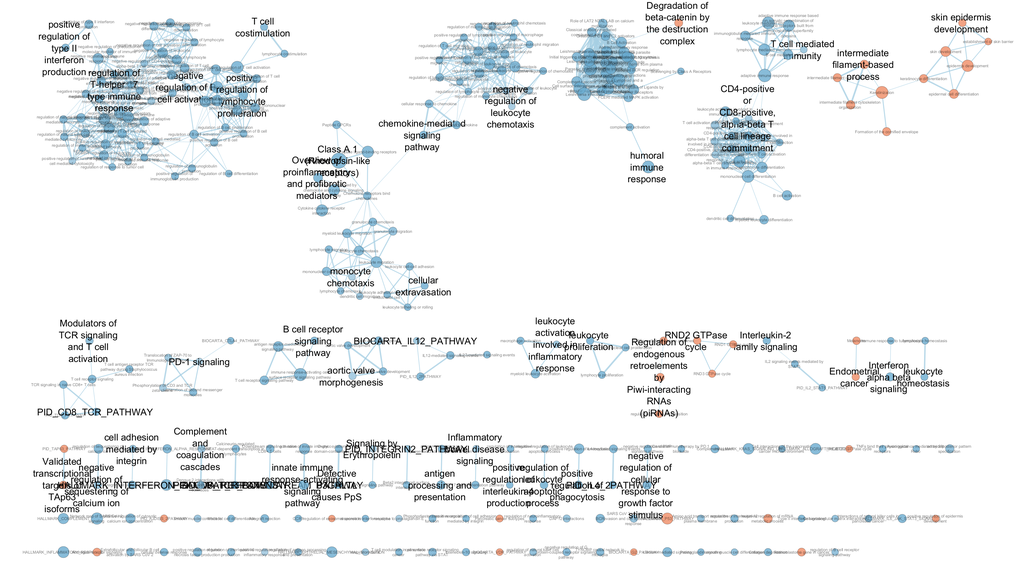

```r
knitr::include_graphics("Tumour_Vs_PDO.png")
```

### 2.3 Make a publication ready figure - include this figure with proper legends in your notebook.

Using the above parameters and by checking the Publication-Ready check box, the following figure is created:

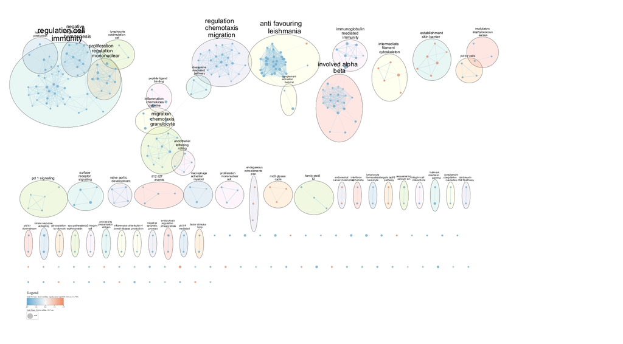

```r
knitr::include_graphics("Annotated_EM_pub_ready.png")
```

**Figure 2.** *Enrichment map of the significant gene sets and pathways, after annotation and layout adjustments. Each node represent a pathway, with red representing up-regulation and blue representing down-regulation. Edges represent similarity between the pathways with thicker edge corresponding to higher similarity score. The Publication-Ready box is checked and figure is manually adjusted to be more compact.*

For better readability, here is an image of the Legend:

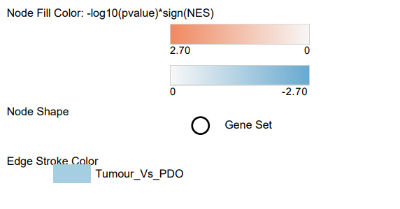

```r
knitr::include_graphics("Legend.png")
```

**Figure 3.** *Enlarged Legend for Figure 2.*

### 2.4 Collapse your network to a theme network. What are the major themes present in this analysis? Do they fit with the model? Are there any novel pathways or themes?

The theme network is generated by clicking “Collapse All” to group gene sets with a single theme node using the AutoAnnotate function. I manually expanded the top three clusters for better look at the major themes.

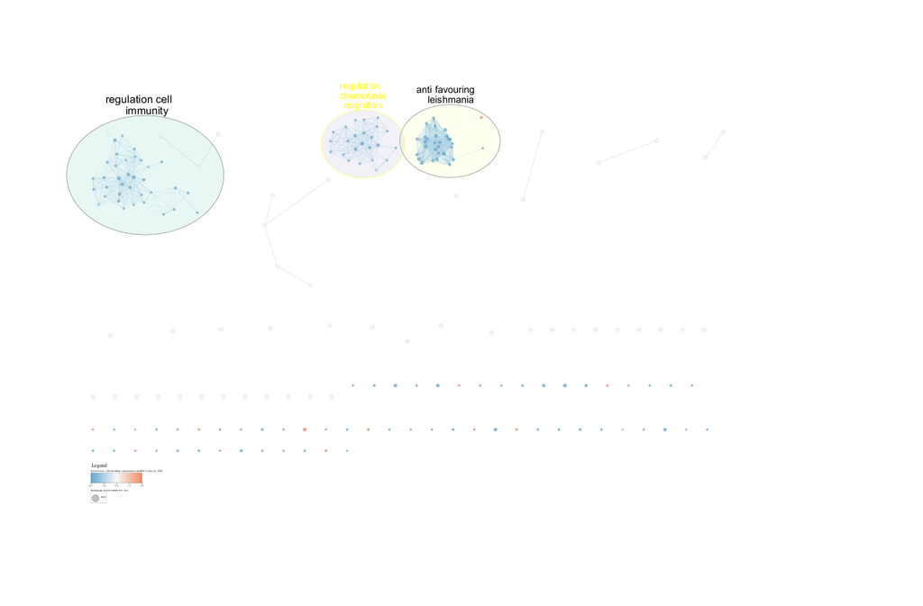

```r
knitr::include_graphics("theme.png")
```

**Figure 4.** *Theme network of the significant gene sets and pathways after collapsing all clusters and expanding the top three clusters. Each node represent a pathway, with red representing up-regulation and blue representing down-regulation. Edges represent similarity between the pathways with thicker edge corresponding to higher similarity score. The Publication-Ready box is checked and figure is manually adjusted to be more compact.*

- Regulation of Chemotaxis Migration: Chemotaxis, the movement of cells in response to chemical stimuli, is a key mechanism in cancer metastasis. This theme might include pathways that facilitate tumor cell migration or the recruitment of immune cells to the tumor microenvironment. Understanding these pathways can help in identifying potential targets for preventing metastasis or enhancing immune cell infiltration into tumors.
- Anti-favouring Leishmania: This theme seems initially unrelated to lung cancer; however, it might highlight underlying immune responses or signaling pathways that are similarly exploited in different disease contexts, such as infectious diseases and cancer. The immune system’s mechanisms to combat pathogens (like Leishmania) might share pathways with those engaged in battling cancer cells, potentially offering insights into nonspecific immune activation or suppression observed in lung cancer. This theme could represent a novel pathway or a niche area of study within the broader research context. It could introduce new perspectives or mechanisms previously unconsidered or underexplored in the model.

The identified themes of “Regulation of Cell Immunity” and “Regulation of Chemotaxis Migration” fit exceptionally well with the model of modeling lung adenocarcinoma metastases using patient-derived organoids. This model explores the tumor microenvironment and the interaction between cancer cells and the immune system, which are crucial for understanding how lung adenocarcinoma spreads and responds to treatments(Liu et al., 2024). The focus on cell immunity is particularly relevant, as it highlights the immune landscape’s role in either promoting or inhibiting metastatic spread. Similarly, the theme of chemotaxis migration aligns with the study of how cancer cells migrate and invade new tissues—an essential aspect of metastasis. Both themes are integral to developing more effective therapeutic strategies in organoid models, which aim to replicate the complex biological interactions found in patients more accurately than traditional in vitro models.

## Interpretation

### 3.1 Do the enrichment results support conclusions or mechanism discussed in the original paper? How do these results differ from the results you got from Assignment #2 thresholded methods.

The enrichment results from the analysis, which include upregulated themes related to skin development processes like “Keratinization,” “Formation of the Cornified Envelope,” and “Epidermis Development,” as well as downregulated themes involving immune interactions and complement pathways, support several conclusions and mechanisms discussed in the original paper on modeling lung adenocarcinoma metastases using patient-derived organoids. The original paper discusses the role of the in vivo PDO metastasis model in elucidating mechanisms of resistance to targeted therapy and in identifying personalized immune-priming strategies. These topics correlate well with the downregulation of immune-related pathways such as “Immunoregulatory Interactions between a Lymphoid and a Non-Lymphoid Cell” and “Complement Cascade.” Such downregulation could reflect the complex interplay between the tumor microenvironment and the immune system, which the paper addresses when discussing the use of PDOs cocultured with PBMCs to determine optimal immune-priming strategies. Moreover, the upregulated pathways related to skin development may not directly correspond to lung adenocarcinoma’s typical pathways but could signify epithelial-related processes that are active in the organoid models. This might suggest a degree of organoid adaptation or specific signaling pathways being studied that are also active in skin-related tissues or processes of epithelial differentiation that are common in various carcinomas, including lung adenocarcinoma. Therefore, while the direct connection between skin development pathways and lung adenocarcinoma isn’t immediately apparent, the mechanisms related to cellular differentiation and immune modulation highlighted in the enrichment results do align with the discussions in the original paper about organoid behavior, metastatic modeling, and the immune environment’s role in cancer progression and response to therapy. This suggests that the organoids may be capturing critical aspects of tumor biology that are relevant both in the direct context of lung cancer and in broader cancer biology.

The comparison between results from Assignment #2’s thresholded Over-Representation Analysis (ORA) and Assignment #3’s Gene Set Enrichment Analysis (GSEA) highlights distinct thematic focuses due to their methodological differences. ORA results are concentrated primarily on specific cellular activities and signaling pathways such as smooth muscle differentiation and BMP signaling, reflecting the most significantly altered pathways. In contrast, GSEA reveals a broader scope of biological processes, particularly emphasizing immune system interactions and skin development processes. GSEA’s ability to assess enrichment across all ranked genes allows it to capture both dominant and subtler biological themes, thus providing a more comprehensive view of the dataset’s underlying biological dynamics compared to the more narrowly focused ORA.

### 3.2 Can you find evidence, i.e. publications, to support some of the results that you see. How does this evidence support your result?

Furthermore, another detailed study integrated transcriptomic, methylomic, and miRNA profiles to identify key regulators of keratinization in lung squamous cell carcinoma, another non-small cell lung cancer subtype closely related to LUAD. This research identified critical genes and pathways that could also be relevant in the context of LUAD due to similar underlying epithelial cell mechanisms(Heryanto & Imoto, 2023).

These studies provide a solid foundation of evidence that supports the biological relevance of the pathways identified in your enrichment analysis, reinforcing the potential for these pathways to serve as targets for diagnostics or therapeutic interventions in lung adenocarcinoma.

### 3.3 Choose a specific pathway or theme to investigate in more detail. Why did you choose this pathway or theme? Show the pathway or theme as a gene network or as a pathway diagram. Annotate the network or pathway with your original log fold expression values and p-values to show how it is effected in your model. (Hint: if the theme or pathway is not from database that has detailed mechanistic information like Reactome you can use apps like GeneMANIA or String to build the the interaction network.)

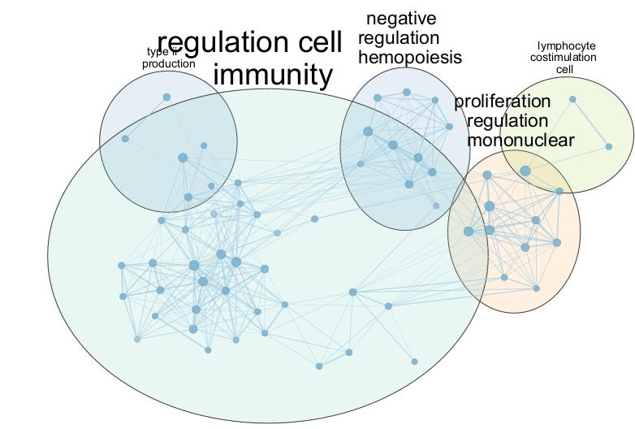

```r
knitr::include_graphics("gene_network.png")
```

**Figure 5.** *Gene network of Regulation Cell Immunity*

## Link to Journal

[Assignment 3](https://github.com/bcb420-2025/Keren_Zhang/wiki/Assignment-3)

## References

The R packages used in the analysis include: `GEOquery` (Davis & Meltzer, 2007), `edgeR` (Chen, Chen, Lun, Baldoni, & Smyth, 2025), `biomaRt` (Durinck, Spellman, Birney, & Huber, 2009), `ggplot2` (Wickham, 2016), `dplyr` (Wickham, François, Henry, Müller, & Vaughan, 2023), `tidyr` (Wickham, Vaughan, & Girlich, 2024), `limma` (Ritchie et al., 2015), `circlize` (Gu, Gu, Eils, Schlesner, & Brors, 2014), `gprofiler2` (Kolberg, Raudvere, Kuzmin, Vilo, & Peterson, 2020), `kableExtra` (Zhu, 2024) and `knitr` (Xie, 2024).

Chen, Y., Chen, L., Lun, A. T. L., Baldoni, P. L., & Smyth, G. K. (2025). edgeR v4: Powerful differential analysis of sequencing data with expanded functionality and improved support for small counts and larger datasets. *Nucleic Acids Research*, *53*(2), gkaf018. https://doi.org/10.1093/nar/gkaf018

Davis, S., & Meltzer, P. (2007). GEOquery: A bridge between the gene expression omnibus (GEO) and BioConductor. *Bioinformatics*, *14*, 1846–1847.

Durinck, S., Spellman, P., Birney, E., & Huber, W. (2009). Mapping identifiers for the integration of genomic datasets with the r/bioconductor package biomaRt. *Nature Protocols*, *4*, 1184–1191. https://doi.org/10.1038/nprot.2009.97

*Enrichment map gene sets*. (2025). University of Toronto, Bader Lab. Retrieved from http://download.baderlab.org/EM_Genesets/current_release/Human/symbol/

Gu, Z., Gu, L., Eils, R., Schlesner, M., & Brors, B. (2014). Circlize implements and enhances circular visualization in r. *Bioinformatics*, *30*, 2811–2812.

Heryanto, Y. D., & Imoto, S. (2023). Identifying key regulators of keratinization in lung squamous cell cancer using integrated TCGA analysis. *Cancers*, *15*(7). https://doi.org/10.3390/cancers15072066

Kolberg, L., Raudvere, U., Kuzmin, I., Vilo, J., & Peterson, H. (2020). gprofiler2– an r package for gene list functional enrichment analysis and namespace conversion toolset g:profiler. *F1000Research*, *9 (ELIXIR)*(709).

Liu, Y., Lankadasari, M., Rosiene, J., Johnson, K., Zhou, J., Bapat, S., … Jones, D. (2024). Modeling lung adenocarcinoma metastases using patient-derived organoids. *Cell Rep Med*, *5*(10), 101777. https://doi.org/10.1016/j.xcrm.2024.101777

Ritchie, M. E., Phipson, B., Wu, D., Hu, Y., Law, C. W., Shi, W., & Smyth, G. K. (2015). limma powers differential expression analyses for RNA-sequencing and microarray studies. *Nucleic Acids Research*, *43*(7), e47. https://doi.org/10.1093/nar/gkv007

Subramanian, A., Tamayo, P., Mootha, V. K., Mukherjee, S., Ebert, B. L., Gillette, M. A., … Mesirov, J. P. (2005). Gene set enrichment analysis: A knowledge-based approach for interpreting genome-wide expression profiles. *Proceedings of the National Academy of Sciences*, *102*(43), 15545–15550. https://doi.org/10.1073/pnas.0506580102

Wickham, H. (2016). *ggplot2: Elegant graphics for data analysis*. Springer-Verlag New York. Retrieved from https://ggplot2.tidyverse.org

Wickham, H., François, R., Henry, L., Müller, K., & Vaughan, D. (2023). *Dplyr: A grammar of data manipulation*. Retrieved from https://CRAN.R-project.org/package=dplyr

Wickham, H., Vaughan, D., & Girlich, M. (2024). *Tidyr: Tidy messy data*. Retrieved from https://CRAN.R-project.org/package=tidyr

Xie, Y. (2024). *Knitr: A general-purpose package for dynamic report generation in r*. Retrieved from https://yihui.org/knitr/

Zappa, C., & Mousa, S. A. (2016). Non-small cell lung cancer: Current treatment and future advances. *Translational Lung Cancer Research*, *5*(3), 288–300. https://doi.org/10.21037/tlcr.2016.06.07

Zhu, H. (2024). *kableExtra: Construct complex table with ’kable’ and pipe syntax*. Retrieved from http://haozhu233.github.io/kableExtra/